# Literature review classification

## Introduction

The purpose of this paper is to determine how to automatically classify literature review genres.

# Methodology

We use the five step process of knowledge-discovery in database.

# Step 01: Data Selection

We start by performing text mining on teh abstract of articles classed as “meta-reviews” by Templier and Paré (2018). Link: https://www.tandfonline.com/doi/abs/10.1080/0960085X.2017.1398880

Accordingly, this paper analyses 142 abstracts of literature reviews.

A polarized wordcloud allows to graphically assess whether there are word associated to one specific genre in the literature.

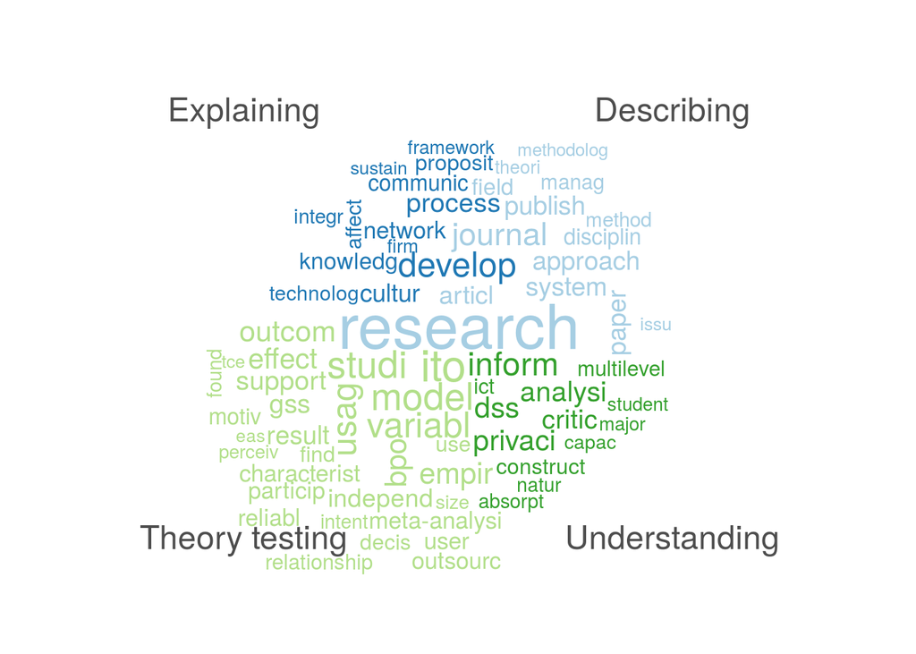

# Step 02: Data Pre-processing

We start by associating to each abstract a set of information, and by analysis the frequency of appeareance of each word in the text.

```
##                                                                                                                                                                                                                   Authors
## 1                                         Ahuja, M. K. (2002). Women in the information technology profession: A literature review, synthesis and research agenda. European Journal of Information Systems, 11(1), 20–34.
## 2                              Akhlaghpour, S., Wu, J., Lapointe, L., & Pinsonneault, A. (2013). The ongoing quest for the IT artifact: Looking back, moving forward. Journal of Information Technology, 28(2), 150–166.
## 3                                                    Aksulu, A., & Wade, M. (2010). A comprehensive review and synthesis of open source research. Journal of the Association for Information Systems, 11(11/12), 576–656.
## 4 Alaghehband, F. K., Rivard, S., Wu, S., & Goyette, S. (2011). An assessment of the use of transaction cost theory in information technology outsourcing. The Journal of Strategic Information Systems, 20(2), 125–138.
## 5                                           Alavi, M., & Leidner, D. E. (2001). Review: Knowledge management and knowledge management systems: Conceptual foundations and research issues. MIS Quarterly, 25(1), 107–136.
##   paper critic analys natur state
## 1     0      0      0     0     0
## 2     2      0      0     0     0
## 3     1      0      0     0     1
## 4     1      0      0     1     0
## 5     3      0      0     0     0
```

# Step 03: Data transformation

To perform an automatic classification, we add the type of review as a dependent variable.

```
##      Types paper critic analys natur state
## 1 Critical     0      0      0     0     0
## 2 Critical     2      0      0     0     0
## 3 Critical     1      0      0     0     1
## 4 Critical     1      0      0     1     0
## 5 Critical     3      0      0     0     0
## 6 Critical     2      1      1     1     2
```